# Mini Proyecto 2020. Datos Tráfico

Tratamiento de Datos, Grado en Ciencia de Datos - UV

Stefan Lahud García, Olivia Sarahì Vargas Vásquez

2020-05-12

# 1 Tareas realizadas por cada uno de los miembros del equipo:

## 1.1 Stefan. Lahud (*coordinador*). Tareas:

- **Tarea 1.1.** Importación de los datos de forma ineficiente: importación de cada fichero por separado.
- **Tarea 1.2.** Imputación de datos dentro del conjunto TD: TD_imputados.
  - **1.2.1.** Obtención de valores promedio según cada hora del dataframe.
  - **1.2.2.** Introducción de los mismos dentro de cada valor faltante.
- **Tarea 1.3.** Búsqueda de errores en la introducción de datos mediante los tres parámetros propuestos.
- **Tarea 1.4.** Obtención de la visualización de valores frontera máximos.
- **Tarea 1.5.** Obtención de matriz de datos estadísticos.
  - **1.5.1.** Creación del conjunto de datos TD_horas.
  - **1.5.1.** Creación y visualización del conjunto de datos TD_horas_stats.
- **Tarea 1.6.** Creación del gráfico “Distribución de intensidades ligeras y pesadas promedio, por carril, mes y año”.
- **Tarea 1.7.** Creación del gráfico “Distribución de la velocidad, por carril, hora y año”.
- **Tarea 1.8** Creción del gráfico “Representación estadística de la distancia media entre vehículos”.
- **Tarea 1.9** Obtención del dataframe TD_cat, a partir de los datos estadísticos obtenidos en TD_horas_stats.

## 1.2 Sarahí. Vargas. Tareas:

- **Tarea 2.1.** Importación de los datos de forma práctica: utilización de apply() y rbind() para automatizar la tarea.
- **Tarea 2.2.** Obtención del conjunto de datos completo TD.
  - **2.2.1.** Creación del vector cortes, para segmentar TD por fechas.
  - **2.2.2.** Introducción de fechas faltantes.
  - **2.2.3.** Manejo de variables tipo fecha e introducción de variables nuevas como semana y día de la semana.
  - **2.2.4.** Sustitución de puntos dentro de los nombres de TD.
  - **2.2.5.** Verificación de código, utilizando como referencia un número de filas igual a carriles * años * días * horas * minutos.
- **Tarea 2.3.** Creación del gráfico “Distribución de los datos con datos imputados y sin datos imputados ni ceros”.
- **Tarea 2.4.** Creación de los 3 gráficos “Capacidad en intensidad total admisible por carril”.
- **Tarea 2.5.** Creación del gráfico “Representación de velocidad media con respecto a la ocupación, según el carril y el año”.
- **Tarea 2.6.** Análisis bivariante.
  - **2.6.1.** Creación de la matriz de correlación.
  - **2.6.2.** Visualización del test de normalidad.
- **Tarea 2.7.** Obtención de pruebas Chi Cuadrado y representación en gráficos de mosaico.
- **Tarea 2.8.** Redacción.

# 2 Introducción y objetivos

El objetivo de este trabajo es enfrentar un problema de tratamiento de datos que abarque todas las etapas que se han visto a lo largo del curso de Tratamiento de Datos, resolviendo los problemas que se vayan generando de forma autónoma. Dichas etapas son:

1. Importación de datos.
2. Visualización de datos.
3. Manejo de datos.
4. Análisis exploratorio.

En este proyecto se analizarán un conjunto de datos reales proporcionados por la empresa **CPS Infraestructuras, Movilidad y Medio ambiente (www.cps.es)**, exclusivamente con la finalidad de realizar este proyecto. Así mismo, se dividirá en las siguientes fases:

0. Lectura de la documentación **(Codebook)** proporcionada con los datos.
1. Importación de datos **./data**
2. Acondicionamiento de los datos para que se correspondan con un `tidy data`.
3. Análisis exploratorio. - ¿Qué datos tenemos? - ¿Qué análisis podemos plantearnos? - ¿Qué podemos buscar en estos datos?
4. Utilización de todas las herramientas que se han ido viendo a lo largo del curso, para analizar y describir los datos (análisis univariante, bivariante, relaciones entre variables, etc), inclusión de información adicional que se considere que pueda ser de utilidad (enriquecimiento de los datos).

# 3 Importación de los datos

Para comenzar con el trabajo, es necesario importar los ficheros de los cuatro carriles para cada año, es decir, ocho **data frames**. A continuación, se explica el proceso paso a paso:

1. Utilizar la librería **readr**
2. **read.csv.** Lectura de archivos con extensión .csv; se selecciona como separador al punto y coma (sep = “;”), indicando que el fichero tiene cabecera, y que no se desean convertir las cadenas de texto a factores.
3. **list.files.** Obtención de un listado -ordenado- de los ficheros que se encuentran dentro de la carpeta **data**.
4. **lapply.** Aplicación de la función **read.csv** en el listado ordenado obtenido con **list.files** todo guardado en un `Large list` llamado **import** con los ocho ficheros.
5. **rbind.** Utilizada a la par con `do.call` sobre **import** para concatenar los ocho ficheros en uno solo, llamado **All**.
6. Asignación del formato **NA** a las coincidencias con **\N**, ya que, como se indica en el Codebook, ésta ha sido la forma de representar a los valores faltantes.

Data summary

| Name | All |
| --- | --- |
| Number of rows | 3392132 |
| Number of columns | 7 |
| _______________________ |  |
| Column type frequency: |  |
| character | 7 |
| ________________________ |  |
| Group variables | None |

**Variable type: character**

| skim_variable | n_missing | complete_rate | min | max | empty | n_unique | whitespace |
| --- | --- | --- | --- | --- | --- | --- | --- |
| fecha.y.hora | 0 | 1.00 | 15 | 16 | 0 | 854270 | 0 |
| intensidad.total | 745608 | 0.78 | 1 | 2 | 0 | 49 | 0 |
| intensidad.ligeros | 745608 | 0.78 | 1 | 2 | 0 | 49 | 0 |
| intensidad.pesados | 745608 | 0.78 | 1 | 2 | 0 | 19 | 0 |
| velocidad.media | 745608 | 0.78 | 1 | 3 | 0 | 234 | 0 |
| ocupacion | 745608 | 0.78 | 1 | 3 | 0 | 101 | 0 |
| distancia.media.entre.vehiculos | 745608 | 0.78 | 1 | 3 | 0 | 256 | 0 |

Se tiene ahora un **dataframe** llamado All, que contiene la concatenación de los años 2017 y 2018 según el carril, de forma ordenada; sin embargo, se desea colocar un identificador de carril, para saber la información de qué carril proviene. Para ello se crea el vector `cortes`. En él, se utiliza la función **grep** para identificar las observaciones en donde la variable `fecha.y.hora` comience por `01/01/` y termine por `0:00`, mediante la utilización de la expresión regular:

`pattern = "^01/01/.* 0:00$"`

Es decir, se encontrarán las (ocho) filas en donde esté presente el primer minuto del primer día del año. De esta manera, sabremos colocar el carril de donde proviene la información.

Se procede a introducir toda la información a un solo **dataframe** llamado `TD`. A continuación, se explicará cada función en orden de aparición:

1. TD resulta de una transformación del **dataframe All**.
2. **mutate.** Convierte a la variable `fecha.y.hora` en tipo **DateTime** con ayuda de la función dmy_hm de la librería lubridate; también, crea la variable `carril` a partir del vector previamente definido `cortes` y una concatenación de funciones **ifelse()**.
3. **complete.** Con ayuda de la función **seq.POSIXt**, ayuda a completar el dataframe con las fechas y horas omitidas en los documentos originales.
4. **mutate.** Crea las variables `semana` y `dia_semana`, quienes, gracias a las funciones **week** y **wday** de la librería **lubridate**, obtienen valores de número de semana y nombre del día de la semana, respectivamente.
5. **arrange.** Permite ordenar los datos según la fecha y hora.
6. **separate.** Uso de la función en tres ocasiones para dividir la columna `fecha.y.hora`, quien contiene toda la información temporal, en cinco variables independientes: `año`, `mes`, `día`, `hora`, `minutos`.
7. **select.** Reorden de las columnas dentro del **dataframe** (estético).
8. **mutate_if.** Función que convierte las variables incialmente consideradas como caracteres en el **dataframe All**, en numéricas.
9. **mutate.**. Conversión de la variable `carril` en factor, y conversión de la variable `mes` de número a factor, utilizando la función **month**.
10. **colnames**. Finalmente, se utiliza la función **gsub** para sustituir los puntos leídos en las cabeceras del dataframe, por espacios. Por ejemplo: `fecha.y.hora` por `fecha y hora`

# 4 Imputación de datos

1. TD_imputados resulta de una transformación del **dataframe TD**.
2. **select.** Selecciona columnas importantes del **dataframe TD**, como lo son `año`, `hora`, `carril` y todas las variables numéricas.
3. **group_by.** Se agrupa el data frame por `año`, `hora` y `carril`, de tal forma que se obtendrá un total de 2 * 24 * 4 = 192 grupos.
4. **summarise_at.** Para cada grupo, y para cada variable numérica, crea las variables `VarNum_mean` correspondiente a la media de la variable en el grupo correspondiente. Por ejemplo, la media de la variable `intensidad total` en el año 2017 a la hora 0, en el carril 1.
5. **ungroup.** Permite desagrupar.
6. **right_join.** Gracias a esta función, se unen el **dataframe** que se ha ido trabajando, junto con el **dataframe** original **TD**, de tal forma que, ahora, se cuenta con una varible extra `VarNum_mean` por cada columna numérica existente `VarNum`
7. **mutate.** Ahora, para cada variable numérica, se hace una lectura de si su valor es o no es **NA** con la función **ifelse** y **is.na()**: si existe un valor, lo mantiene; si no, inserta el valor obtenido en `VarNum_mean`.
8. **mutate_if.** Función que convierte las variables incialmente consideradas como caracteres en el **dataframe All**, en numéricas.
9. **select.** Función utilizada en dos ocasiones, con la finalidad de quitar del dataframe las columnas `VarNum_mean` -ya que ya realizaron su trabajo- y reorganizar las variables restantes (estética).

Una vez realizado el nuevo **dataframe**, se utilizan las funciones **kable** y **head** para mostrar los primeros quince valores del **dataframe TD_imputados** y desplegarlos de la manera más estética posible dentro del documento HTML ejecutado.

Cabecera para Datos de Tráfico 2017-2018

| carril | semana | dia_semana | dia | mes | anio | hora | minutos | intensidad total | intensidad ligeros | intensidad pesados | velocidad media | ocupacion | distancia media entre vehiculos |
| --- | --- | --- | --- | --- | --- | --- | --- | --- | --- | --- | --- | --- | --- |
| 1 | 0 | domingo | 1 | ene | 2017 | 0 | 0 | 0 | 0 | 0 | 0 | 0 | 0 |
| 2 | 0 | domingo | 1 | ene | 2017 | 0 | 0 | 0 | 0 | 0 | 0 | 0 | 0 |
| 3 | 0 | domingo | 1 | ene | 2017 | 0 | 0 | 2 | 2 | 0 | 119 | 0 | 165 |
| 4 | 0 | domingo | 1 | ene | 2017 | 0 | 0 | 0 | 0 | 0 | 0 | 0 | 0 |
| 1 | 0 | domingo | 1 | ene | 2017 | 0 | 1 | 0 | 0 | 0 | 0 | 0 | 0 |
| 2 | 0 | domingo | 1 | ene | 2017 | 0 | 1 | 0 | 0 | 0 | 0 | 0 | 0 |
| 3 | 0 | domingo | 1 | ene | 2017 | 0 | 1 | 2 | 2 | 0 | 132 | 0 | 183 |
| 4 | 0 | domingo | 1 | ene | 2017 | 0 | 1 | 0 | 0 | 0 | 0 | 0 | 0 |
| 1 | 0 | domingo | 1 | ene | 2017 | 0 | 2 | 0 | 0 | 0 | 0 | 0 | 0 |
| 2 | 0 | domingo | 1 | ene | 2017 | 0 | 2 | 0 | 0 | 0 | 0 | 0 | 0 |
| 3 | 0 | domingo | 1 | ene | 2017 | 0 | 2 | 2 | 2 | 0 | 111 | 0 | 255 |
| 4 | 0 | domingo | 1 | ene | 2017 | 0 | 2 | 0 | 0 | 0 | 0 | 0 | 0 |
| 1 | 0 | domingo | 1 | ene | 2017 | 0 | 3 | 1 | 1 | 0 | 117 | 0 | 186 |
| 2 | 0 | domingo | 1 | ene | 2017 | 0 | 3 | 0 | 0 | 0 | 0 | 0 | 0 |
| 3 | 0 | domingo | 1 | ene | 2017 | 0 | 3 | 1 | 1 | 0 | 101 | 0 | 255 |

Data summary

| Name | TD_imputados |
| --- | --- |
| Number of rows | 4204800 |
| Number of columns | 14 |
| _______________________ |  |
| Column type frequency: |  |
| factor | 3 |
| numeric | 11 |
| ________________________ |  |
| Group variables | None |

**Variable type: factor**

| skim_variable | n_missing | complete_rate | ordered | n_unique | top_counts |
| --- | --- | --- | --- | --- | --- |
| carril | 0 | 1 | FALSE | 4 | 1: 1051200, 2: 1051200, 3: 1051200, 4: 1051200 |
| dia_semana | 0 | 1 | TRUE | 7 | dom: 604800, lun: 604800, mar: 599040, mié: 599040 |
| mes | 0 | 1 | TRUE | 12 | ene: 357120, mar: 357120, may: 357120, jul: 357120 |

**Variable type: numeric**

| skim_variable | n_missing | complete_rate | mean | sd | p0 | p25 | p50 | p75 | p100 | hist |
| --- | --- | --- | --- | --- | --- | --- | --- | --- | --- | --- |
| semana | 0 | 1 | 25.57 | 15.05 | 0 | 13.00 | 26.00 | 39.00 | 52 | ▇▇▇▇▇ |
| dia | 0 | 1 | 15.72 | 8.80 | 1 | 8.00 | 16.00 | 23.00 | 31 | ▇▇▇▇▆ |
| anio | 0 | 1 | 2017.50 | 0.50 | 2017 | 2017.00 | 2017.50 | 2018.00 | 2018 | ▇▁▁▁▇ |
| hora | 0 | 1 | 11.50 | 6.92 | 0 | 5.75 | 11.50 | 17.25 | 23 | ▇▇▆▇▇ |
| minutos | 0 | 1 | 29.50 | 17.32 | 0 | 14.75 | 29.50 | 44.25 | 59 | ▇▇▇▇▇ |
| intensidad total | 0 | 1 | 5.97 | 7.18 | 0 | 0.27 | 3.00 | 9.00 | 49 | ▇▂▁▁▁ |
| intensidad ligeros | 0 | 1 | 5.72 | 7.08 | 0 | 0.22 | 2.82 | 9.00 | 49 | ▇▂▁▁▁ |
| intensidad pesados | 0 | 1 | 0.25 | 0.57 | 0 | 0.00 | 0.00 | 0.28 | 18 | ▇▁▁▁▁ |
| velocidad media | 0 | 1 | 74.31 | 46.73 | 0 | 17.39 | 93.13 | 110.15 | 254 | ▆▆▇▁▁ |
| ocupacion | 0 | 1 | 6.09 | 12.83 | 0 | 0.22 | 2.00 | 6.00 | 100 | ▇▁▁▁▁ |
| distancia media entre vehiculos | 0 | 1 | 114.40 | 81.14 | 0 | 39.24 | 116.00 | 179.70 | 255 | ▇▅▇▆▃ |

Por último, se crea el **dataframe TD_no_zero**, que nace de la ideología de obtener un **dataframe** con únicamente los datos de cuando **un automovil ha pasado durante el minuto de observación**, es decir, un **dataframe** sin filas llenas de ceros ni valores faltantes.

1. TD_no_zero resulta de una transformación del **dataframe TD**.
2. **drop_na.** Elimina observaciones del **dataframe TD**, donde todas las variables numéricas estén faltantes: desde `intensidad total` hasta `ditancia media entre vehiculos`.
3. **filter_if.** Se filtra con la misma ideología que con **drop_na()** pero ahora, con la condición de que todos los valores de todas las variables numéricas, sean igual a 0.

# 5 Búsqueda de errores en los datos

Es importante, antes de comenzar con un análisis en los datos, buscar errores en la introducción de los mismos, así como valores máximos y mínimos **a priori**. Para ello, se comprueban tres parámetros:

1. Si el valor de `intensidad total` es cero, entonces el de `velocidad media` también debe de serlo, y viceversa. En otras palabras, esta situación sería incoherente y, por ende, deberíamos de ver si existen o no dicha situación. A continuación se muestra la diferencia entre el número de filas antes y después del filtrado.

```
[1] 0
```

2. Corroborar si hay o no algún *NA*. Se utilizan las funciones **any** y **is.na()**.

```
[1] FALSE
```

3. Confirmar si hay algún valor negativo. Se crea una función que busca si hay algún valor negativo en los datos de una fila, y es aplicada mediante **apply** a las filas de los datos numéricos de TD_imputados. Finlamente, se busca si hay algún resultado `Verdadero`.

```
[1] FALSE
```

Esto quiere decir que no hay incongruencias en los datos y que tampoco existen valores faltantes. Sin embargo, es importante recalcar que estos *tests* no tienen nada que ver en cuestión de *datos anómalos* sino que solo descarta el hecho de tener errores en la introducción de datos o, en su defecto, la omisión de alguno.

# 6 Valores frontera (máximos)

| semana | dia | anio | hora | minutos | intensidad total | intensidad ligeros | intensidad pesados | velocidad media | ocupacion | distancia media entre vehiculos |
| --- | --- | --- | --- | --- | --- | --- | --- | --- | --- | --- |
| 52 | 31 | 2018 | 23 | 59 | 49 | 49 | 18 | 254 | 100 | 255 |
| 52 | 31 | 2018 | 23 | 59 | 49 | 49 | 17 | 254 | 100 | 255 |
| 52 | 31 | 2018 | 23 | 59 | 47 | 47 | 17 | 254 | 100 | 255 |
| 52 | 31 | 2018 | 23 | 59 | 47 | 47 | 17 | 254 | 100 | 255 |
| 52 | 31 | 2018 | 23 | 59 | 46 | 46 | 16 | 254 | 100 | 255 |
| 52 | 31 | 2018 | 23 | 59 | 46 | 46 | 16 | 254 | 100 | 255 |

# 7 Estadísticos de los datos

Así, obtenemos un **dataframe** con los valores estadísticos por variable y por hora.

Ahora bien, a partir del conjunto obtenido, se obtiene otro conjunto llamado **TD_horas_stats**, que muestra las estadísticas de una forma ordenada. Se obtiene como se muestra a continuación:

1. TD_horas_stats resulta de una transformación del **dataframe TD_horas**.
2. **select.** Selecciona únicamente las columnas numéricas del **dataframe TD_horas**.
3. **summarise_all.** Para cada variable numérica, crea una variables correspondiente al promedio, la desviacióne estándar, la mediana, el rango intercuartil y los cuartiles de 25% y 75%.
4. **ungroup.** Permite desagrupar.
5. **gather.** Se utiliza para convertir la información en una tabla larga, de tal forma que los nombres de las variables pasan a ser nombres de una variable llamada `Variables` y sus valores se almacenan en otra columna llamada `Valores`.
6. **separate.** Utilizada para separar, mediante el caracter "_", la columna `Variables` en dos columnas: `Variables` y `stat`.
7. **spread.** Ahora bien, se reagrupan los valores dentro de la variable `stat` de nuevo en una tabla de forma larga, con dichos valores como nombres de variables.

Una vez realizado el nuevo **dataframe**, se utilizan las funciones **kable** y **head** para mostrar los valores del **dataframe TD_horas_stats** y desplegarlos de la manera más estética posible dentro del documento HTML ejecutado.

| Variable | Mediana | Desv.est | Q05 | Q25 | Promedio | Q75 | Q95 | IQR |
| --- | --- | --- | --- | --- | --- | --- | --- | --- |
| distancia media entre vehiculos | 117.7 | 27.6 | 57.4 | 99.2 | 114.4 | 133.3 | 155.9 | 34.1 |
| intensidad ligeros | 1563.4 | 936.5 | 83.6 | 307.0 | 1372.9 | 2069.0 | 2835.4 | 1762.0 |
| intensidad pesados | 45.2 | 58.2 | 4.4 | 19.9 | 60.9 | 80.4 | 171.0 | 60.5 |
| intensidad total | 1615.2 | 973.6 | 92.0 | 332.0 | 1433.8 | 2173.6 | 2942.9 | 1841.6 |
| ocupacion | 4.9 | 5.1 | 0.2 | 2.5 | 6.1 | 9.1 | 16.3 | 6.6 |
| velocidad media | 79.7 | 24.0 | 26.9 | 58.2 | 74.3 | 96.0 | 104.2 | 37.8 |

# 8 Visualización de los datos

En este apartado, se buscará y desarrollará código que conteste ciertas preguntas. Es decir, gráficas y representaciones visuales de las preguntas planteadas.

## 8.1 Distribución de los datos con datos imputados y sin datos imputados ni ceros

**¿Cómo se distribuyen los datos en los diferentes dataframes obtenidos?** Para contestar a esta pregunta, se procede de la siguiente manera:

1. Se utiliza al **dataframe TD_imputados** y **TD_no_zero** respectivamente.
2. **select.** Selecciona todas las variables numéricas que surgen de una medición previa, es decir, desde `intensidad total` hasta `distancia media entre vehiculos`.
3. **gather.** Con la finalidad de mostrar los datos, toda la selección se convierte en una tabla larga, donde en la columna `Medición` se encuentra el nombre de la medición y en la columna `Valor`, se encuentra el valor de dicha medición.
4. **mutate.** Convierte la variable `Medición` en tipo factor.
5. **ggplot().** Comienza a graficar, poniendo en el eje de las abscisas a la variable `Medición` y en el eje de las ordenadas al eje `Valor`, coloreando así por cada tipo distinto de `Medición`.
6. **geom_boxplot().** Representación de la información en forma de caja y bigotes.
7. **theme_bw().** Estilo de la gráfica.

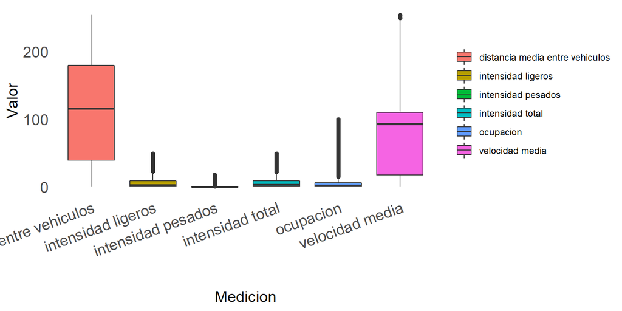

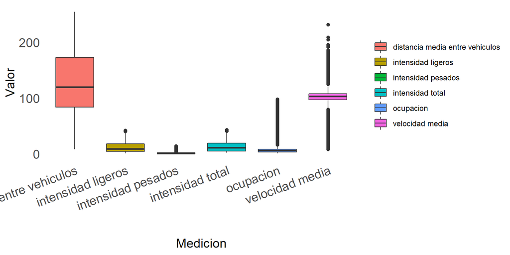

Podemos notar cómo la distribución de los datos depende fuertemente de los datos eliminados, ya que éstos si éstos no son eliminados -es decir, datos faltantes imputados y filas con ceros- entonces aportarán a la obtención de datos estadísticos como los cuantiles, el promedio o la mediana. Dicho de otra forma, la concentración de los valores será distinta.

## 8.2 Capacidad en intensidad total admisible por carril

**¿Cómo se distribuyen los datos referentes a la intensidad total por hora?**

Ahora, antes de progresar, se deberá corroborar que -atendiendo a lo adoptado en HCM 2000 (high capacity Manual)- la intensidad no podrá ser superior a la intensidad máxima admisible configurada para el tipo de vía considerada en cada caso. La capacidad de una vía de alta capacidad es 2400 vehículos a la hora por carril. Para contestar a esta pregunta, se procede de la siguiente manera:

Obtención del primer dataframe **Q1**.

1. Se utiliza al **dataframe TD_imputados**.
2. **select.** Selecciona todas las variables numéricas que surgen de una medición previa, es decir, desde `intensidad total` hasta `distancia media entre vehiculos`, así como las partes de fecha referentes a la hora: `año`, `mes`, `día`, `hora`.
3. **group_by.** Se agrupa la información ahora por cada hora en el **dataframe** y por `carril`.
4. **summarise.** Obtiene la suma (minuto a minuto, por hora) de la `intensidad total`, para obtener la intensidad total por hora.
5. **mutate.** Se utiliza para categorizar la variable `intensidad total` guardada en `Nivel de intensidad` en cuatro categorías:
1. Para intensidades menores a 800, se clasificará como **BAJA**.
2. Para intensidades menores a 1600, se clasificará como **MEDIA**.
3. Para intensidades menores a 2400, se clasificará como **ALTA**.
4. Para cualquier otra intensidad, se clasificará como **EXCESIVA**.

Obtención de dataframe secundario **Q1.1**. **Tabla de frecuencias** 1. Se utiliza al **dataframe Q1**. 2. **group_by.** Se agrupa la información ahora por cada categoría en el `Nivel de intensidad`. 3. **summarise.** Obtiene el número de repeticiones de cada categoría. 4. **mutate.** Se ordenan los niveles del factor `Nivel de intensidad`.

Ahora, resultan tres gráficos: a) El primer gráfico resulta en una comparativa entre casos categorizados del nivel de intensidad por hora, de forma que se ve una perspectiva según el **número de casos** por categoría. b) El segundo gráfico muestra un contenido similar, ahora se muestra la comparativa entre casos categorizados, de forma porcentual en un gráfico de pastel. c) Finalmente, se muestran un gráfico de violín, separado por carril, en donde se muestra visualmente la distribución de los datos de cada carril. Así mismo se sitúa una línea horizontal marcando el límite de los 2400 vehículos a la hora por carril -atendiendo a lo adoptado en HCM 2000 (high capacity Manual)-, viendo claramente cómo en ningún momento en los años recopilados, se cruzó dicho umbral.

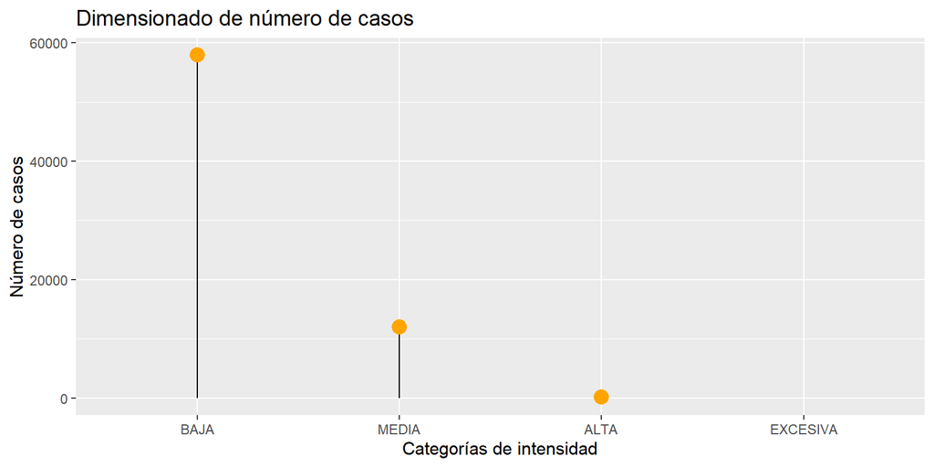

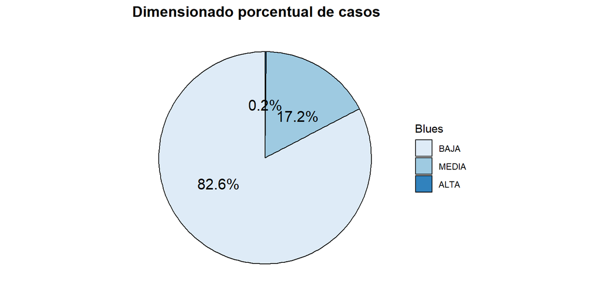

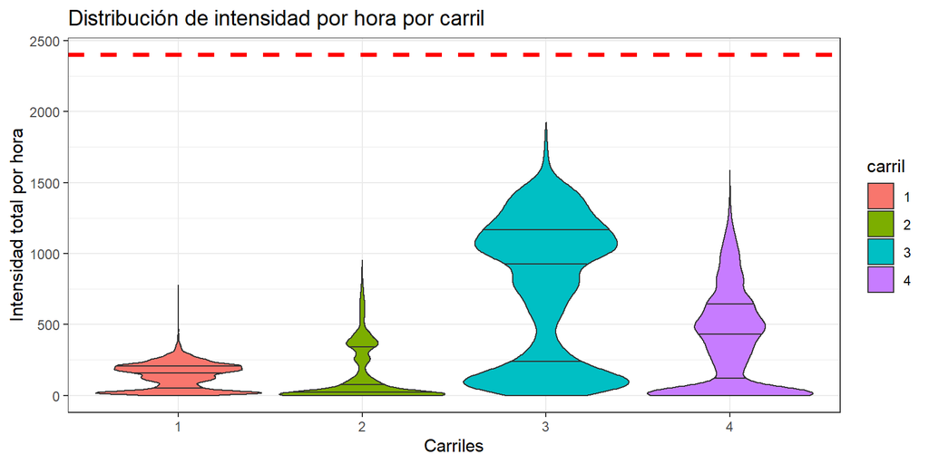

## 8.3 Distribución de intensidades ligeras y pesadas promedio, por carril, mes y año

**¿Cómo se distribuyen los datos referentes a la intensidad ligeros e intensidad pesados según el carril y el mes?**

Obtención del dataframe **Q2**.

1. Se utiliza al **dataframe TD_imputados**.
2. **group_by.** Se agrupa la información ahora por cada mes en el **dataframe** y por `carril`.
3. **summarise.** Obtiene la suma (minuto a minuto, por mes) de la `intensidad ligeros` y la `intensidad pesados`, para obtener el total de cada tipo de intensidad mensual.
4. **gather.** Para poder graficar la información, se utiliza esta función que tranforma el tipo de tabla a una tabla larga en donde, para cada agrupación, exite una variable llamada `Tipo de intensidad` que tiene por valores `ligeros` y `pesados`, y otra variable `Intensidad` que tiene su valor.

La gráfica resultante es una gráfica en donde se muestran 8 casos, separados por carril y por año. En cada uno e ellos, se muestra la relación entre `intensidad ligeros` e `intensidad pesados` de forma mensual. La intensidad se muestra representada en uno por cada mil.

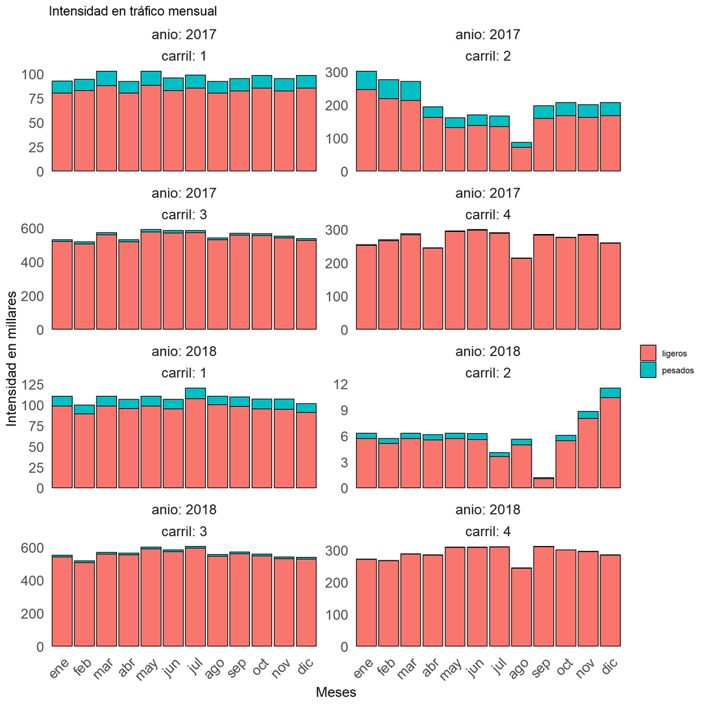

## 8.4 Distribución de la velocidad, por carril, hora y año

**¿Cómo se distribuyen los datos referentes a la velocidad media según el carril y la hora?**

Obtención del dataframe **Q3**.

1. Se utiliza al **dataframe TD_imputados**.
2. **select.** Selecciona todas las variables numéricas que surgen de una medición previa, es decir, desde `intensidad total` hasta `distancia media entre vehiculos`, así como las variables `año`, `hora` y `carril`.
3. **group_by.** Se agrupa la información ahora por cada año y hora en el **dataframe** y por `carril`.
4. **summarise.** Obtiene la media de la `velocidad media`, para obtener su valor respecto a la hora del día por año.

La gráfica resultante es una gráfica en donde se muestran 8 casos, separados por carril y por año. En cada uno e ellos, el desarrollo de la `velocidad media` de forma horaria, es decir, por cada hora en cada día del año -en promedio- qué valor adquiere la `velocidad media`. Así mismo, se le ha agregado una línea de densidad, para observar con mayor nitidez el comportamiento de la variable.

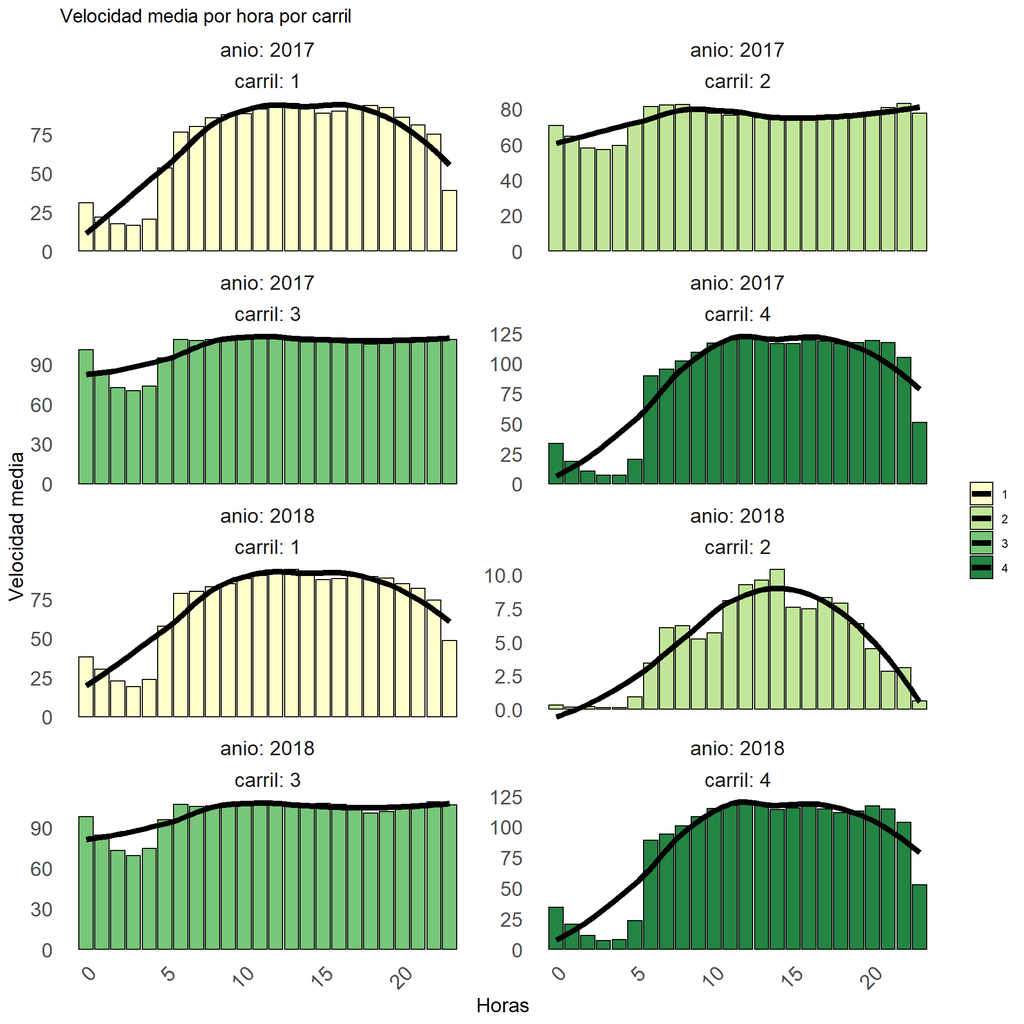

## 8.5 Representación de velocidad media con respecto a la ocupación, según el carril y el año

Se inicia por la búsqueda de una relación entre dos variables que llaman la atención: `ocupación` y `velocidad media` y, para ver aún más allá, se segmentará la información por `año` y `carril`.

Obtención del dataframe **Q4**.

1. Se utiliza al **dataframe TD_imputados**.
2. **select.** Selecciona las variables de interés: `velocidad media` y `ocupación`, así como las variables `año`, `mes`, ``día` y `carril`.
3. **group_by.** Se agrupa la información ahora por año, mes y día en el **dataframe** y por `carril`.
4. **summarise_at.** Obtiene la media tanto de la `velocidad media` como de la `ocupación`, para obtener su valor respecto al día del año.

La gráfica resultante muestra un punto por cada día en el conjunto original, es decir, 730 puntos, aproximadamente, por carril. Así mismo, se encuentra la información separada por carril y por año, por color y forma, respectivamente.

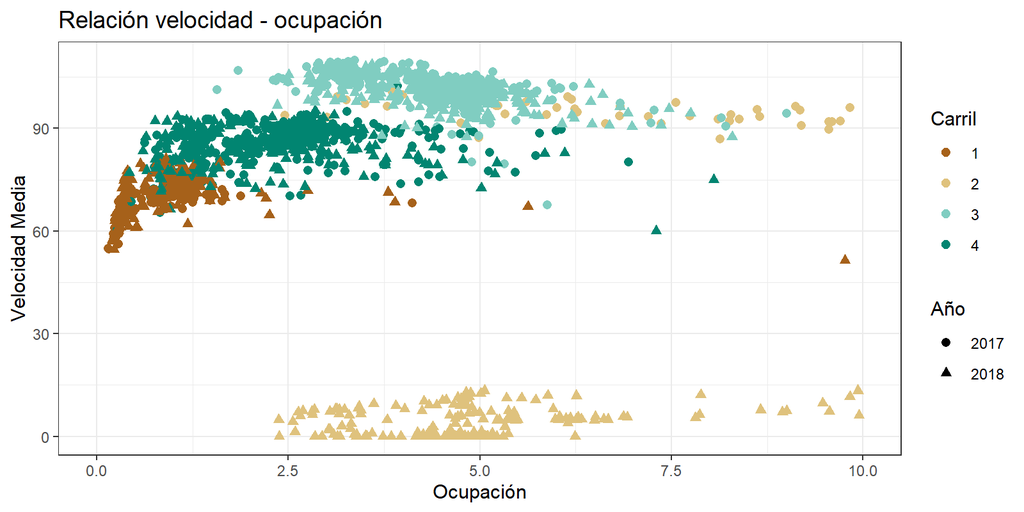

Las deducciones a obtener a partir de esta gráfica son:

1. Podemos deducir a simple vista que los carriles 1, 3 y 4 no resultan afectados por la distinción de año, sin embargo, la distribución del carril 2 cambia radicalmente, en parte, por lo visto en la gráfica anterior.
2. Es posible, a grandes rasgos, definir los siguientes pares según la agrupación de puntos:
- **carril 1** - ocupación 1.0% - velocidad 70 km/h.
  - **carril 2** - ocupación 5.0% - velocidad 95 km/h - año 2017.
  - **carril 2** - ocupación 5.0% - velocidad 10 km/h - año 2018.
  - **carril 3** - ocupación 4.5% - velocidad 100 km/h.
  - **carril 4** - ocupación 2.5% - velocidad 85 km/h.

## 8.6 Representación estadística de la distancia media entre vehículos

Este apartado es un poco especial, se busca responder a la siguiente pregunta. Si estoy viendo un automóvil en la carretera en una semana particular, **¿con qué certeza encontraré su distancia con el vehículo más próximo?**

Obtención del dataframe **Q5**.

1. Se utiliza al **dataframe TD_no_zeros**, ya que la pregunta supone que se está observando a un automóvil, por lo tanto, se deben de considerar datos en donde exista información sobre automóviles en ese momento.
2. **select.** Selecciona las variables de interés: `distancia media entre vehículos`, `año` y `semana`.
3. **group_by.** Se agrupa la información ahora por año y semana.
4. **summarise.** Se obtienen los cuantiles importantes para la variable en cuestión. Dichos cuantiles serán 5%, 25%, 50%, 75% y 95%.

La gráfica resultante muestra una sucesión de áreas, cada una indicando al cuantil indicado anteriormente, con la finalidad de mostrar la distribución de la variable mediante cuantiles según la semana.

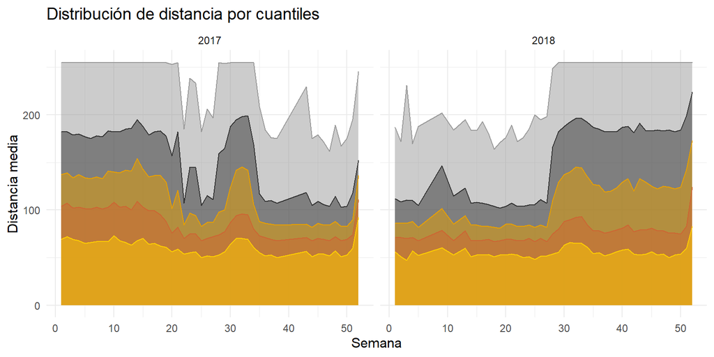

# 9 Análisis bivariante

## 9.1 Matriz de correlación

Ahora, llegados a este punto, hemos encontrado que el carril 3, es el que presenta una distribución de datos más estable, ya que en los análisis ha sido el menos fluctuante y con una distribución mayor que la del resto (ej. intensidad total), por lo tanto, se procede a obtener la matriz de correlación entre todas las variables numéricas del carril 3.

1. Se utiliza al **dataframe TD_no_zeros**, ya que se espera obtener una correlación entre las veces en las que se obtuvo alguna información.
2. **select.** Selecciona las variables medidas, así como la variable `carril`.
3. **filter.** Selecciona únicamente observaciones pertinentes al carril 3.
4. **select.** Elimina a la variable `carril`.
5. **ggpairs().** Función de la librería GGally, que muestra la matriz de correlación entre las variables.

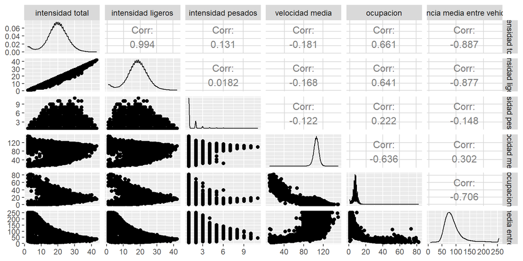

¿Qué pares de variables tienen un coeficiente de correlación superior al 0.8 o inferior a -0.8?

- `intensidad total` e `intensidad ligeros`
  - `intensidad total` y `distancia media entre vehículos`
  - `intensidad ligeros` y `distancia media entre vehículos`

¿Qué pares de variables están vagamente relacionada?

- `intensidad pesados` e `intensidad ligeros`
  - `intensidad pesados` y `velocidad media`

## 9.2 Distribución normal

Ahora bien, el histograma proporcionado para la variable `intensidad total` simula una distribución normal, pero, ¿lo será?

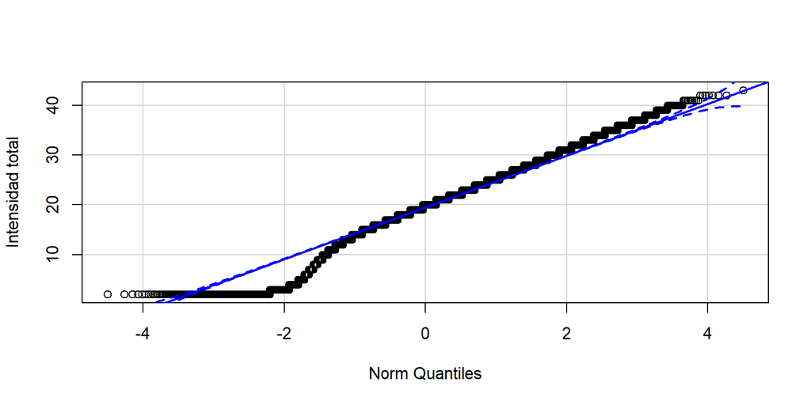

Cerca, pero no. Ninguna variable sigue una distribución normal.

## 9.3 Relación entre variables categóricas

Finalmente, se obtiene una conjunto de datos **categorizado**, es decir, que las variables numéricas serán transformadas a factores, según su propio valor. Estos factores serán:

- **“MB”** - Muy Bajo
  - **“B”** - Bajo
  - **“M”** - Medio
  - **“A”** - Alto
  - **“MA”** - Muy Alto

Y serán obtenidos a partir de los cuartiles 5%, 25%, 75% y 95% obtenidos en el **dataframe TD_horas** y **TD_horas_stats**. El dataframe resultante será nombrado como **TD_cat**.

1. Se utiliza al **dataframe TD_horas**.
2. **mutate.** Con ayuda de la función **ifelse()**, factoriza a cada variable numérica con sus propios valores de cuantiles dentro de **TD_horas_stats**.
3. **mutate_if.** Como todas las columnas resultan ser caracteres, hace factor a dichas columnas mediante la función **factor()**, ordenando sus niveles de la manera: levels = c(“MB”,“B”,“M”,“A”,“MA”).

## 9.4 Test Chi cuadrada y gráfico de mosaico

Por último, existen procedimientos que permiten determinar la asociación entre 2 variables categóricas. A continuación, se hará el **test Chi cuadrado, χ2**, que toma valor 0 cuando son independientes y mayor que cero cuando hay cierto grado de dependencia, y prestaremos especial atención al **valor-p**, el cual, de ser menor a 0.05, indicará que existe una dependencia entre dichas variables.

TEST CHI CUADRADA: `ocupacion` y `velocidad media`.

```
    Pearson's Chi-squared test

data:  table(TD_cat$ocupacion, TD_cat$`velocidad media`)
X-squared = 14848, df = 16, p-value < 2.2e-16
```

Es posible observar que el **valor-p** es menor a 0.05, lo cual indica **dependencia**. Se procederá a mostrar dicha dependencia categórica en una gráfica de mosaico.

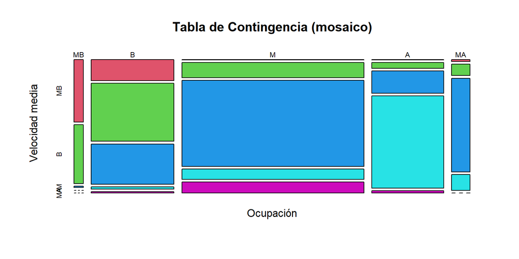

TEST CHI CUADRADA: `intensidad total` y `distancia media entre vehiculos`.

```
    Pearson's Chi-squared test

data:  table(TD_cat$`intensidad total`, TD_cat$`distancia media entre vehiculos`)
X-squared = 21877, df = 16, p-value < 2.2e-16
```

Es posible observar que el **valor-p** es menor a 0.05, lo cual indica **dependencia**. Se procederá a mostrar dicha dependencia categórica en una gráfica de mosaico.

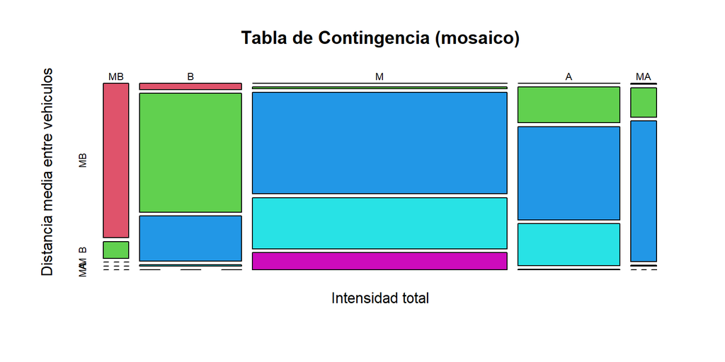